# Solution-Copy17

## Import modules

```python
import pandas as pd
import numpy as np

%matplotlib inline
import matplotlib.pyplot as plt
import matplotlib.ticker as mticker
import seaborn as sns
from datetime import date
from datetime import datetime

from scipy import stats
# from scipy.stats import boxcox
from scipy.special import boxcox, inv_boxcox

import math
```

```python
import start
```

```
Initial setup completed.
```

```python
from helper import *
```

```
Helper Imported.
```

## Load Data

```python
valid_data = pd.read_json (r'validbets.json')
invalid_data = pd.read_json (r'invalidbets.json')
```

```python
valid_data.head()
```

|  | _id | stake | type | placedDate | horse | betRate | marketId | IP | eventType | userName | selectionName | marketName | event | averagePriceMatched | status | winnerId |
| --- | --- | --- | --- | --- | --- | --- | --- | --- | --- | --- | --- | --- | --- | --- | --- | --- |
| 0 | 60337ca8cc80710087ff5d8c | 500.000 | BACK | 2021-02-22T09:43:04.686Z | 8776882 | 1.020 | 1.180 | 2401:4900:30e5:71f1:a86c:d186:5d52:3fa8 | Tennis | brovinn | Danielle Rose Collins | Match Odds | Saisai Zheng v Danielle Rose Collins | 1.020 | WINNER_DECLARED | 8776882 |
| 1 | 60337d5dcc80710087ff5d90 | 2100.000 | LAY | 2021-02-22T09:46:05.458Z | 8776882 | 1.010 | 1.180 | 49.36.123.125 | Tennis | aksash111 | Danielle Rose Collins | Match Odds | Saisai Zheng v Danielle Rose Collins | 1.010 | WINNER_DECLARED | 8776882 |
| 2 | 60337b0a13046300869b42c4 | 25000.000 | LAY | 2021-02-22T09:36:10.372Z | 8776882 | 1.060 | 1.180 | 2405:201:25:d0aa:11b4:2e1c:9999:f32a | Tennis | pinka2 | Danielle Rose Collins | Match Odds | Saisai Zheng v Danielle Rose Collins | 1.050 | WINNER_DECLARED | 8776882 |
| 3 | 60337ae4b0517a00b16380e8 | 300.000 | LAY | 2021-02-22T09:35:32.772Z | 8776882 | 1.070 | 1.180 | 2401:4900:30e5:71f1:a86c:d186:5d52:3fa8 | Tennis | brovinn | Danielle Rose Collins | Match Odds | Saisai Zheng v Danielle Rose Collins | 1.070 | WINNER_DECLARED | 8776882 |
| 4 | 60337ab7f343e00049c69416 | 500.000 | BACK | 2021-02-22T09:34:47.648Z | 8776882 | 1.080 | 1.180 | 2401:4900:30e5:71f1:a86c:d186:5d52:3fa8 | Tennis | brovinn | Danielle Rose Collins | Match Odds | Saisai Zheng v Danielle Rose Collins | 1.080 | WINNER_DECLARED | 8776882 |

```python
print("Valid Data Shape : ",valid_data.shape)
print("No. of Data points : ", valid_data.shape[0])
print("No. of Fetures : ", valid_data.shape[1]-1)
```

```
Valid Data Shape :  (10000, 16)
No. of Data points :  10000
No. of Fetures :  15
```

```python
invalid_data.head(3)
```

|  | _id | stake | type | placedDate | horse | betRate | marketId | IP | eventType | userName | selectionName | marketName | event | averagePriceMatched | status | winnerId |
| --- | --- | --- | --- | --- | --- | --- | --- | --- | --- | --- | --- | --- | --- | --- | --- | --- |
| 0 | 5fa47215305f1f00f02b5ae4 | 783758 | LAY | 2020-11-05T21:43:49.222Z | 127991 | 160.000 | 1.175 | 185.105.2.158 | Soccer | contra11 | AC Milan | Match Odds | AC Milan v Lille | 160.000 | INVALID_BET | 44790 |
| 1 | 5fa014d9d1a79f00d41349df | 4500 | BACK | 2020-11-02T14:16:57.494Z | 22121561 | 1.960 | 1.175 | 106.204.14.80 | Cricket | sirsa3 | Delhi Capitals | Match Odds | Delhi Capitals v Royal Challengers Bangalore | 1.970 | INVALID_BET | 22121561 |
| 2 | 5fa014db5a7a0a00e2868190 | 7000 | BACK | 2020-11-02T14:16:59.763Z | 22121561 | 1.960 | 1.175 | 185.203.122.18 | Cricket | bhush001 | Delhi Capitals | Match Odds | Delhi Capitals v Royal Challengers Bangalore | 1.960 | INVALID_BET | 22121561 |

```python
print("Invalid Data Shape : ",invalid_data.shape)
print("No. of Data points : ", invalid_data.shape[0])
print("No. of Fetures : ", invalid_data.shape[1]-1)
```

```
Invalid Data Shape :  (66, 16)
No. of Data points :  66
No. of Fetures :  15
```

## Merge Data

```python
merged_data = pd.concat([valid_data,invalid_data])
```

```python
merged_data.head(3)
```

|  | _id | stake | type | placedDate | horse | betRate | marketId | IP | eventType | userName | selectionName | marketName | event | averagePriceMatched | status | winnerId |
| --- | --- | --- | --- | --- | --- | --- | --- | --- | --- | --- | --- | --- | --- | --- | --- | --- |
| 0 | 60337ca8cc80710087ff5d8c | 500.000 | BACK | 2021-02-22T09:43:04.686Z | 8776882 | 1.020 | 1.180 | 2401:4900:30e5:71f1:a86c:d186:5d52:3fa8 | Tennis | brovinn | Danielle Rose Collins | Match Odds | Saisai Zheng v Danielle Rose Collins | 1.020 | WINNER_DECLARED | 8776882 |
| 1 | 60337d5dcc80710087ff5d90 | 2100.000 | LAY | 2021-02-22T09:46:05.458Z | 8776882 | 1.010 | 1.180 | 49.36.123.125 | Tennis | aksash111 | Danielle Rose Collins | Match Odds | Saisai Zheng v Danielle Rose Collins | 1.010 | WINNER_DECLARED | 8776882 |
| 2 | 60337b0a13046300869b42c4 | 25000.000 | LAY | 2021-02-22T09:36:10.372Z | 8776882 | 1.060 | 1.180 | 2405:201:25:d0aa:11b4:2e1c:9999:f32a | Tennis | pinka2 | Danielle Rose Collins | Match Odds | Saisai Zheng v Danielle Rose Collins | 1.050 | WINNER_DECLARED | 8776882 |

```python
print("Data Shape : ",merged_data.shape)
print("No. of Data points : ", merged_data.shape[0])
print("No. of Fetures : ", merged_data.shape[1]-1)
```

```
Data Shape :  (10066, 16)
No. of Data points :  10066
No. of Fetures :  15
```

```python
heading('Backup copy of Data')
original_data = merged_data.copy()
print("Data Shape : ",original_data.shape)
print("No. of Data points : ", original_data.shape[0])
print("No. of Fetures : ", original_data.shape[1]-1)
```

```
-------------------
Backup copy of Data
-------------------
Data Shape :  (10066, 16)
No. of Data points :  10066
No. of Fetures :  15
```

```python
merged_data.to_csv('merge_data.csv', index=False)
```

## Train test spit

```python
from sklearn.model_selection import train_test_split
train, test = train_test_split(merged_data, test_size=0.2, stratify=merged_data['status'])
```

```python
print(train.shape)
print(test.shape)
```

```
(8052, 16)
(2014, 16)
```

```python
train['status'].value_counts()
```

```
WINNER_DECLARED    7999
INVALID_BET          53
Name: status, dtype: int64
```

```python
test['status'].value_counts()
```

```
WINNER_DECLARED    2001
INVALID_BET          13
Name: status, dtype: int64
```

## EDA (Elementary Data Analysis)

## High Level Statistics

```python
valid_data.info()
```

```
<class 'pandas.core.frame.DataFrame'>
RangeIndex: 10000 entries, 0 to 9999
Data columns (total 16 columns):
 #   Column               Non-Null Count  Dtype
---  ------               --------------  -----
 0   _id                  10000 non-null  object
 1   stake                10000 non-null  float64
 2   type                 10000 non-null  object
 3   placedDate           10000 non-null  object
 4   horse                10000 non-null  int64
 5   betRate              10000 non-null  float64
 6   marketId             10000 non-null  float64
 7   IP                   9998 non-null   object
 8   eventType            10000 non-null  object
 9   userName             10000 non-null  object
 10  selectionName        10000 non-null  object
 11  marketName           10000 non-null  object
 12  event                10000 non-null  object
 13  averagePriceMatched  10000 non-null  float64
 14  status               10000 non-null  object
 15  winnerId             10000 non-null  int64
dtypes: float64(4), int64(2), object(10)
memory usage: 1.2+ MB
```

**Observation :**

- IP column have 2 missing values.

```python
invalid_data.info()
```

```
<class 'pandas.core.frame.DataFrame'>
RangeIndex: 66 entries, 0 to 65
Data columns (total 16 columns):
 #   Column               Non-Null Count  Dtype
---  ------               --------------  -----
 0   _id                  66 non-null     object
 1   stake                66 non-null     int64
 2   type                 66 non-null     object
 3   placedDate           66 non-null     object
 4   horse                66 non-null     int64
 5   betRate              66 non-null     float64
 6   marketId             66 non-null     float64
 7   IP                   65 non-null     object
 8   eventType            66 non-null     object
 9   userName             66 non-null     object
 10  selectionName        66 non-null     object
 11  marketName           66 non-null     object
 12  event                66 non-null     object
 13  averagePriceMatched  66 non-null     float64
 14  status               66 non-null     object
 15  winnerId             66 non-null     int64
dtypes: float64(3), int64(3), object(10)
memory usage: 8.4+ KB
```

**Observation :**

- IP column have 1 missing values.

```python
describe(valid_data).T
```

|  | count | mean | std | min | 25% | 50% | 75% | max | mad | skew | kurt |
| --- | --- | --- | --- | --- | --- | --- | --- | --- | --- | --- | --- |
| stake | 10000.000 | 31411.858 | 145336.923 | 9.000 | 367.500 | 2000.000 | 20000.000 | 9300000.000 | 43740.049 | 31.645 | 1747.867 |
| horse | 10000.000 | 4998336.836 | 4887547.417 | 448.000 | 1222344.000 | 4294272.000 | 9630879.000 | 25215583.000 | 3936271.743 | 1.092 | 0.892 |
| betRate | 10000.000 | 2.433 | 13.808 | 1.010 | 1.180 | 1.400 | 1.670 | 1000.000 | 1.920 | 45.182 | 2892.427 |
| marketId | 10000.000 | 1.179 | 0.001 | 1.178 | 1.179 | 1.179 | 1.180 | 1.180 | 0.001 | -1.144 | -0.240 |
| averagePriceMatched | 10000.000 | 2.446 | 13.922 | 1.010 | 1.180 | 1.400 | 1.660 | 1000.000 | 1.945 | 44.474 | 2808.271 |
| winnerId | 10000.000 | 4785643.149 | 4693919.515 | 448.000 | 1222344.000 | 4294272.000 | 9630879.000 | 24301731.000 | 3850048.670 | 0.997 | 0.393 |

**Observation :**

- stake, betRate, averagePriceMatched have high positive skew value, as trail dragging towards the right in their respective distributions.
- stake, betRate, averagePriceMatched have high postive kurt value, as trail higher kurtosis corresponds to greater extremity of deviations (or outliers).

```python
# invalid_data.describe().T
describe(invalid_data).T
```

|  | count | mean | std | min | 25% | 50% | 75% | max | mad | skew | kurt |
| --- | --- | --- | --- | --- | --- | --- | --- | --- | --- | --- | --- |
| stake | 66.000 | 76803.606 | 176754.391 | 100.000 | 4125.000 | 9750.000 | 17657.500 | 783758.000 | 110270.253 | 2.768 | 6.812 |
| horse | 66.000 | 3861662.258 | 7916572.561 | 235.000 | 11411.250 | 86359.000 | 4294272.000 | 36846168.000 | 5163178.950 | 2.867 | 8.511 |
| betRate | 66.000 | 5.463 | 19.664 | 1.020 | 1.492 | 1.980 | 4.000 | 160.000 | 5.507 | 7.727 | 61.263 |
| marketId | 66.000 | 1.178 | 0.002 | 1.175 | 1.176 | 1.179 | 1.179 | 1.179 | 0.001 | -0.946 | -0.538 |
| averagePriceMatched | 66.000 | 5.599 | 19.678 | 1.020 | 1.520 | 2.050 | 4.000 | 160.000 | 5.682 | 7.689 | 60.850 |
| winnerId | 66.000 | 3297048.697 | 6904352.770 | 235.000 | 7461.000 | 58805.000 | 2062982.000 | 36846168.000 | 4581190.086 | 2.906 | 9.411 |

**Observation :**

- stake, betRate, averagePriceMatched have high std deviation.

```python
merged_data.info()
```

```
<class 'pandas.core.frame.DataFrame'>
Int64Index: 10066 entries, 0 to 65
Data columns (total 16 columns):
 #   Column               Non-Null Count  Dtype
---  ------               --------------  -----
 0   _id                  10066 non-null  object
 1   stake                10066 non-null  float64
 2   type                 10066 non-null  object
 3   placedDate           10066 non-null  object
 4   horse                10066 non-null  int64
 5   betRate              10066 non-null  float64
 6   marketId             10066 non-null  float64
 7   IP                   10063 non-null  object
 8   eventType            10066 non-null  object
 9   userName             10066 non-null  object
 10  selectionName        10066 non-null  object
 11  marketName           10066 non-null  object
 12  event                10066 non-null  object
 13  averagePriceMatched  10066 non-null  float64
 14  status               10066 non-null  object
 15  winnerId             10066 non-null  int64
dtypes: float64(4), int64(2), object(10)
memory usage: 1.3+ MB
```

```python
describe(merged_data).T
```

|  | count | mean | std | min | 25% | 50% | 75% | max | mad | skew | kurt |
| --- | --- | --- | --- | --- | --- | --- | --- | --- | --- | --- | --- |
| stake | 10066.000 | 31709.479 | 145600.465 | 9.000 | 400.000 | 2000.000 | 20000.000 | 9300000.000 | 44194.691 | 31.301 | 1723.736 |
| horse | 10066.000 | 4990883.972 | 4913718.664 | 235.000 | 1222344.000 | 4294272.000 | 9628997.250 | 36846168.000 | 3945296.031 | 1.136 | 1.190 |
| betRate | 10066.000 | 2.452 | 13.855 | 1.010 | 1.180 | 1.400 | 1.670 | 1000.000 | 1.951 | 44.571 | 2835.808 |
| marketId | 10066.000 | 1.179 | 0.001 | 1.175 | 1.179 | 1.179 | 1.180 | 1.180 | 0.001 | -1.300 | 0.975 |
| averagePriceMatched | 10066.000 | 2.466 | 13.969 | 1.010 | 1.180 | 1.400 | 1.670 | 1000.000 | 1.977 | 43.882 | 2754.245 |
| winnerId | 10066.000 | 4775882.844 | 4712822.120 | 235.000 | 1221386.000 | 4294272.000 | 9630879.000 | 36846168.000 | 3856511.193 | 1.029 | 0.602 |

**Observation :**

- stake, betRate, averagePriceMatched have high positive skew value, as trail dragging towards the right in their respective distributions.
- stake, betRate, averagePriceMatched have high postive kurt value, as trail higher kurtosis corresponds to greater extremity of deviations (or outliers).

## Data Imbalance

```python
merged_data['status'].value_counts()
```

```
WINNER_DECLARED    10000
INVALID_BET           66
Name: status, dtype: int64
```

```python
def pie_labeling(x):
    print(x)
    return '{:.4f}%\n(#{:.0f})'.format(x, sums.values.sum()*x/100)
```

```
99.3443250656128
0.6556725595146418
```

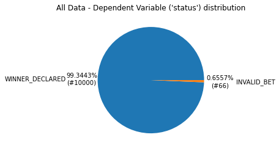

```python
from matplotlib.pyplot import pie, axis, show
sums = merged_data['status'].value_counts()
axis('equal')
pie(sums.values, labels=sums.index, autopct=pie_labeling, pctdistance=1.3, labeldistance=1.6)
plt.title("All Data - Dependent Variable ('status') distribution")

plt.show()
```

```
99.34177994728088
0.6582215428352356
99.35451745986938
0.6454816088080406
```

[figure not shown]

```python
fig = plt.figure(figsize=(24,10))
#this line will produce a figure which has 2 row
#and 4 columns
#(0, 0) specifies the left upper coordinate of your plot
ax1 = plt.subplot2grid((2,4),(0,0))
sums_train = train['status'].value_counts()
plt.pie(sums_train, labels=sums_train.index,autopct=pie_labeling, pctdistance=1.3, labeldistance=1.6)
plt.title('Train Dependent Variable ("status") distribution')
#next one
ax1 = plt.subplot2grid((2, 4), (0, 1))
sums_test = test['status'].value_counts()
plt.pie(sums_test, labels=sums_test.index,autopct=pie_labeling, pctdistance=1.3, labeldistance=1.6)
plt.title('Test Dependent Variable ("status") distribution')

plt.tight_layout()
plt.show()
```

**Observation :**

- Data is highly **imbalanced**.
- **99.34%** data points belongs to **WINNER_DECLARED** while only **0.66%** belongs to **INVALID_BET** category.
- Needs imbalance handling, data upsampling or **class weight balanced** can be use in modeling.

## Check for missing values

```python
merged_data.isnull().values.any()
```

```
True
```

```python
# null_col = merged_data.columns[merged_data.isnull().any()].tolist()
# merged_data[null_col].isnull().sum()
```

```python
# merged_data.isnull().sum()
```

```python
missing_values_table(merged_data)
```

```
Your selected dataframe has 16 columns.
There are 1 columns that have missing values.
```

|  | Missing Values | % of Total Values |
| --- | --- | --- |
| IP | 3 | 0.000 |

**Observation :**

- **IP** column have **3 missing values**.
- We can perform **Data imputation** or drop the missing values rows.
- Since we have small data, we will go for imputation.
- we will deal it later.

## Feature Analysis

```python
heading("Number of unique values in each feature")
print(merged_data.nunique())
```

```
---------------------------------------
Number of unique values in each feature
---------------------------------------
_id                    10066
stake                    376
type                       2
placedDate             10063
horse                    319
betRate                  258
marketId                 390
IP                      1070
eventType                  3
userName                 410
selectionName            318
marketName                10
event                    245
averagePriceMatched      726
status                     2
winnerId                 195
dtype: int64
```

```python
categorical_list = ['type', 'marketId', 'IP', 'eventType', 'userName', 'selectionName', 'marketName', 'event','winnerId']
numerical_list = ['stake', 'horse', 'betRate', 'averagePriceMatched']
datetime_list = ['placedDate']
```

```python
merged_data[numerical_list].nunique()
```

```
stake                  376
horse                  319
betRate                258
averagePriceMatched    726
dtype: int64
```

```python
merged_data[categorical_list].nunique()
```

```
type                2
marketId          390
IP               1070
eventType           3
userName          410
selectionName     318
marketName         10
event             245
winnerId          195
dtype: int64
```

```python
merged_data[datetime_list].nunique()
```

```
placedDate    10063
dtype: int64
```

## _id

```python
merged_data['_id'].nunique()
```

```
10066
```

**Observation :**

- Since **_id** is a **unique identifier** for data points, it should not be used in the modeling.
- We will not include it in modeling.

## Categorical Analysis

```python
heading("Categorical Features")
print('\n'.join(categorical_list))
```

```
--------------------
Categorical Features
--------------------
type
marketId
IP
eventType
userName
selectionName
marketName
event
winnerId
```

## type

```python
# change_dtype_cat(merged_data, 'type', False)
```

```python
# merged_data['type'].dtype
```

```python
merged_data['type'].value_counts()
```

```
LAY     5303
BACK    4763
Name: type, dtype: int64
```

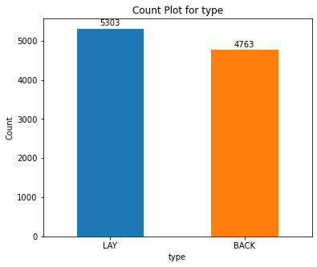

```python
count_plot(merged_data, 'type', rotation=0, size=(6,5))
```

```
----------------------------
type grouped by status Count
----------------------------
```

| status type | INVALID_BET | WINNER_DECLARED |
| --- | --- | --- |
| BACK | 35 | 4728 |
| LAY | 31 | 5272 |

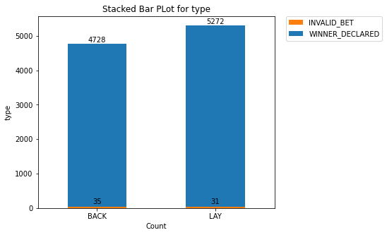

```python
crosstab_by_y_plot(merged_data, 'type', figsize=(6,5))
```

**Observation :**

- Both BACK and LAY category are almost equally distributed.
- BACK have more INVALID_BET compared to LAY, while have less WINNER_DECLARED than LAY.

## marketId

```python
# merged_data['marketId']
```

```python
# change_dtype_cat(merged_data, 'marketId')
```

```python
merged_data['marketId'].nunique()
```

```
390
```

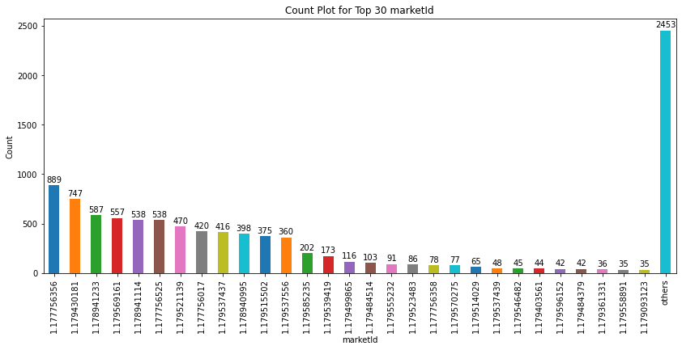

```python
count_plot(merged_data, 'marketId')
```

```python
crosstab_by_y_table(merged_data, 'marketId')
```

```
--------------------------------------------------
Top 10 marketId by WINNER_DECLARED and INVALID_BET
--------------------------------------------------
```

| status marketId | WINNER_DECLARED |
| --- | --- |
| 1.178 | 889 |
| 1.179 | 747 |
| 1.179 | 587 |
| 1.180 | 557 |
| 1.179 | 538 |
| 1.178 | 538 |
| 1.180 | 470 |
| 1.178 | 420 |
| 1.180 | 416 |
| 1.179 | 398 |

| status marketId | INVALID_BET |
| --- | --- |
| 1.179 | 14 |
| 1.179 | 5 |
| 1.176 | 5 |
| 1.179 | 3 |
| 1.175 | 3 |
| 1.179 | 3 |
| 1.175 | 3 |
| 1.176 | 2 |
| 1.179 | 2 |
| 1.176 | 2 |

**Observation :**

- Since matketId should be categorical(Unorderd), but it is more like numerical data.
- So we do numeric analysis.

```python
describe(merged_data['marketId'])
```

|  | count | mean | std | min | 25% | 50% | 75% | max | mad | skew | kurt |
| --- | --- | --- | --- | --- | --- | --- | --- | --- | --- | --- | --- |
| marketId | 10066.000 | 1.179 | 0.001 | 1.175 | 1.179 | 1.179 | 1.180 | 1.180 | 0.001 | -1.300 | 0.975 |

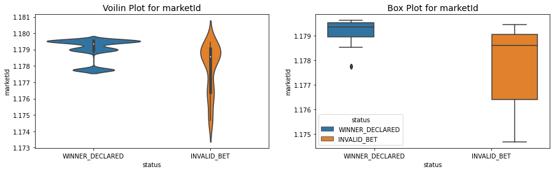

```python
box_violin_plot(merged_data, 'marketId')
```

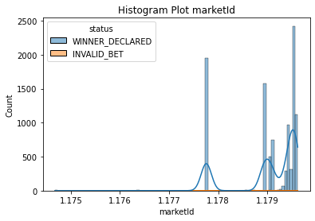

```python
histplot(merged_data, 'marketId')
```

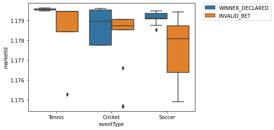

```python
sns.boxplot(x ='eventType', y ='marketId', data = merged_data, hue ='status')
plt.legend(bbox_to_anchor=(1.05, 1), loc=2, borderaxespad=0.)
plt.show()
```

## IP (missing value 3)

```python
merged_data['IP']
```

```
0     2401:4900:30e5:71f1:a86c:d186:5d52:3fa8
1                               49.36.123.125
2        2405:201:25:d0aa:11b4:2e1c:9999:f32a
3     2401:4900:30e5:71f1:a86c:d186:5d52:3fa8
4     2401:4900:30e5:71f1:a86c:d186:5d52:3fa8
                       ...
61                            106.207.179.134
62                             103.200.84.188
63                            103.212.156.208
64                              124.253.0.211
65     2001:8f8:1a63:d2a1:ac87:4f9c:69c9:509e
Name: IP, Length: 10066, dtype: object
```

```python
merged_data['IP'].nunique()
```

```
1070
```

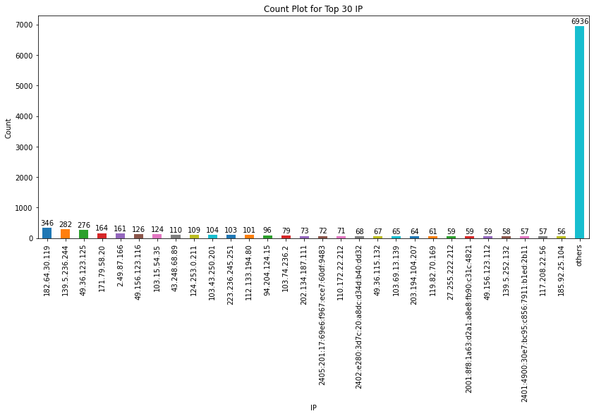

```python
count_plot(merged_data, 'IP')
```

#### Feature Engineering

```python
merged_data['IP_version'] = merged_data['IP'].apply(validIPAddress)
```

```python
merged_data['IP_version'].unique()
```

```
array(['IPv6', 'IPv4', 'Invalid'], dtype=object)
```

```
----------------------------------
IP_version grouped by status Count
----------------------------------
```

| status IP_version | INVALID_BET | WINNER_DECLARED |
| --- | --- | --- |
| IPv4 | 52 | 6418 |
| IPv6 | 13 | 3577 |
| Invalid | 1 | 5 |

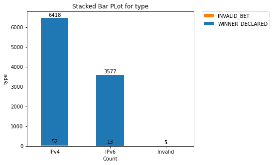

```python
crosstab_by_y_plot(merged_data, 'IP_version', figsize=(6,5))
```

```python
map_data = pd.read_csv('ip_Details_splitted.csv')
```

```python
map_data.head(3)
```

|  | IP | Details | city | region | country | loc | org | postal | timezone |
| --- | --- | --- | --- | --- | --- | --- | --- | --- | --- |
| 0 | 182.64.30.119 | ['Delhi', 'Delhi', 'IN', '28.6519,77.2315', 'AS24560 Bharti Airtel Ltd., Telemedia Services', '1... | Delhi | Delhi | IN | 28.6519,77.2315 | AS24560 Bharti Airtel Ltd., Telemedia Services | 110001 | Asia/Kolkata |
| 1 | 139.5.236.244 | ['Mumbai', 'Maharashtra', 'IN', '19.0728,72.8826', 'AS136334 Vortex Netsol Private Limited', '40... | Mumbai | Maharashtra | IN | 19.0728,72.8826 | AS136334 Vortex Netsol Private Limited | 400070 | Asia/Kolkata |
| 2 | 49.36.123.125 | ['Mumbai', 'Maharashtra', 'IN', '19.0728,72.8826', 'AS55836 Reliance Jio Infocomm Limited', '400... | Mumbai | Maharashtra | IN | 19.0728,72.8826 | AS55836 Reliance Jio Infocomm Limited | 400070 | Asia/Kolkata |

```python
# Ip_data = pd.merge(merged_data, map_data, left_on=  ['IP'],
#                    right_on= ['IP'],
#                    how = 'left')
```

```python
# Ip_data.info()
```

```python
# Ip_data.head(3)
```

```python
merged_data = pd.merge(merged_data, map_data, left_on=  ['IP'],
                   right_on= ['IP'],
                   how = 'left')
```

```python
merged_data.head(3)
```

|  | _id | stake | type | placedDate | horse | betRate | marketId | IP | eventType | userName | selectionName | marketName | event | averagePriceMatched | status | winnerId | IP_version | Details | city | region | country | loc | org | postal | timezone |
| --- | --- | --- | --- | --- | --- | --- | --- | --- | --- | --- | --- | --- | --- | --- | --- | --- | --- | --- | --- | --- | --- | --- | --- | --- | --- |
| 0 | 60337ca8cc80710087ff5d8c | 500.000 | BACK | 2021-02-22T09:43:04.686Z | 8776882 | 1.020 | 1.180 | 2401:4900:30e5:71f1:a86c:d186:5d52:3fa8 | Tennis | brovinn | Danielle Rose Collins | Match Odds | Saisai Zheng v Danielle Rose Collins | 1.020 | WINNER_DECLARED | 8776882 | IPv6 | ['Delhi', 'Delhi', 'IN', '28.6519,77.2315', 'AS45609 Bharti Airtel Ltd. AS for GPRS Service', '1... | Delhi | Delhi | IN | 28.6519,77.2315 | AS45609 Bharti Airtel Ltd. AS for GPRS Service | 110001 | Asia/Kolkata |
| 1 | 60337d5dcc80710087ff5d90 | 2100.000 | LAY | 2021-02-22T09:46:05.458Z | 8776882 | 1.010 | 1.180 | 49.36.123.125 | Tennis | aksash111 | Danielle Rose Collins | Match Odds | Saisai Zheng v Danielle Rose Collins | 1.010 | WINNER_DECLARED | 8776882 | IPv4 | ['Mumbai', 'Maharashtra', 'IN', '19.0728,72.8826', 'AS55836 Reliance Jio Infocomm Limited', '400... | Mumbai | Maharashtra | IN | 19.0728,72.8826 | AS55836 Reliance Jio Infocomm Limited | 400070 | Asia/Kolkata |
| 2 | 60337b0a13046300869b42c4 | 25000.000 | LAY | 2021-02-22T09:36:10.372Z | 8776882 | 1.060 | 1.180 | 2405:201:25:d0aa:11b4:2e1c:9999:f32a | Tennis | pinka2 | Danielle Rose Collins | Match Odds | Saisai Zheng v Danielle Rose Collins | 1.050 | WINNER_DECLARED | 8776882 | IPv6 | ['Airoli', 'Maharashtra', 'IN', '19.1167,72.9833', 'AS55836 Reliance Jio Infocomm Limited', '400... | Airoli | Maharashtra | IN | 19.1167,72.9833 | AS55836 Reliance Jio Infocomm Limited | 400701 | Asia/Kolkata |

```python
missing_values_table(merged_data)
```

```
Your selected dataframe has 25 columns.
There are 9 columns that have missing values.
```

|  | Missing Values | % of Total Values |
| --- | --- | --- |
| postal | 714 | 7.100 |
| Details | 6 | 0.100 |
| city | 6 | 0.100 |
| region | 6 | 0.100 |
| country | 6 | 0.100 |
| loc | 6 | 0.100 |
| org | 6 | 0.100 |
| timezone | 6 | 0.100 |
| IP | 3 | 0.000 |

```python
merged_data[merged_data.isna().any(axis=1)].iloc[:2]
```

|  | _id | stake | type | placedDate | horse | betRate | marketId | IP | eventType | userName | selectionName | marketName | event | averagePriceMatched | status | winnerId | IP_version | Details | city | region | country | loc | org | postal | timezone |
| --- | --- | --- | --- | --- | --- | --- | --- | --- | --- | --- | --- | --- | --- | --- | --- | --- | --- | --- | --- | --- | --- | --- | --- | --- | --- |
| 240 | 603366abdb81de007520b24a | 10000.000 | LAY | 2021-02-22T08:09:15.984Z | 448 | 1.260 | 1.179 |  | Cricket | prakash01 | New Zealand | Match Odds | New Zealand v Australia (1st T20) | 1.240 | WINNER_DECLARED | 448 | Invalid | NaN | NaN | NaN | NaN | NaN | NaN | NaN | NaN |
| 283 | 603364f59dcbc60087fa994a | 7500.000 | BACK | 2021-02-22T08:01:57.076Z | 448 | 1.440 | 1.179 | 94.207.99.8 | Cricket | goat06 | New Zealand | Match Odds | New Zealand v Australia (1st T20) | 1.450 | WINNER_DECLARED | 448 | IPv4 | ['Dubai', 'Dubai', 'AE', '25.0772,55.3093', 'AS15802 Emirates Integrated Telecommunications Comp... | Dubai | Dubai | AE | 25.0772,55.3093 | AS15802 Emirates Integrated Telecommunications Company PJSC | NaN | Asia/Dubai |

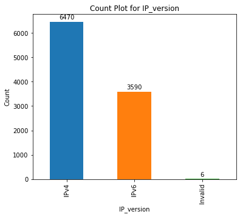

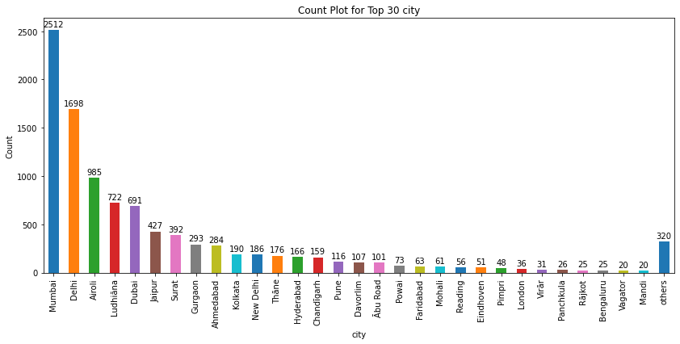

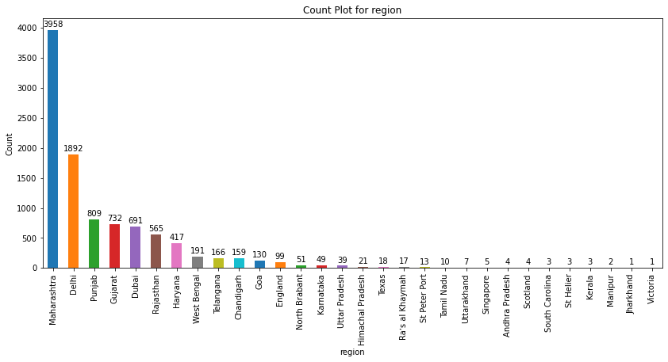

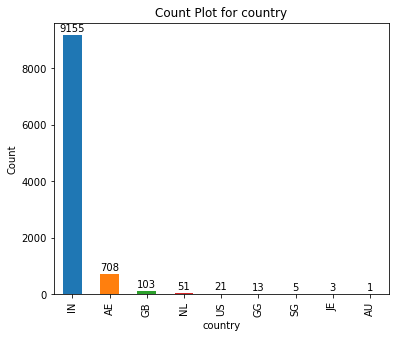

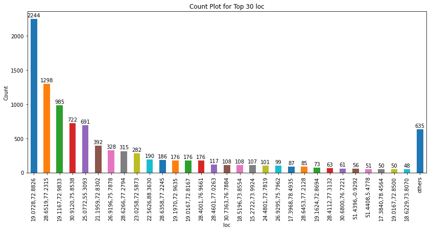

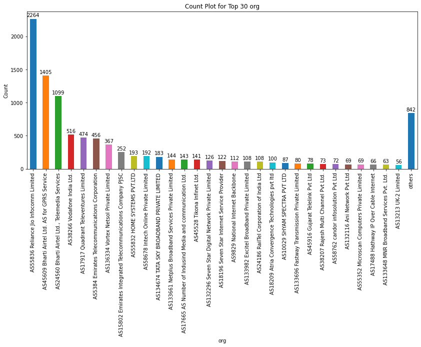

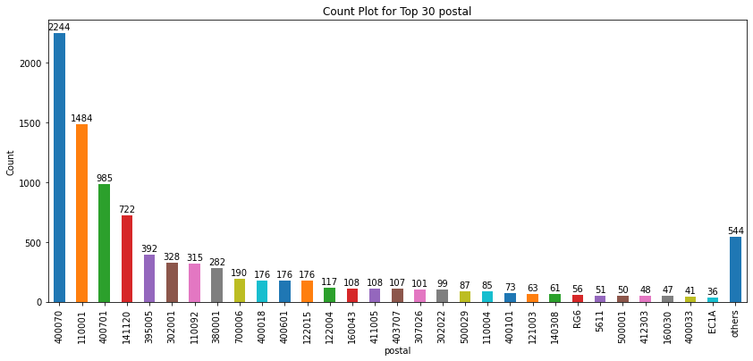

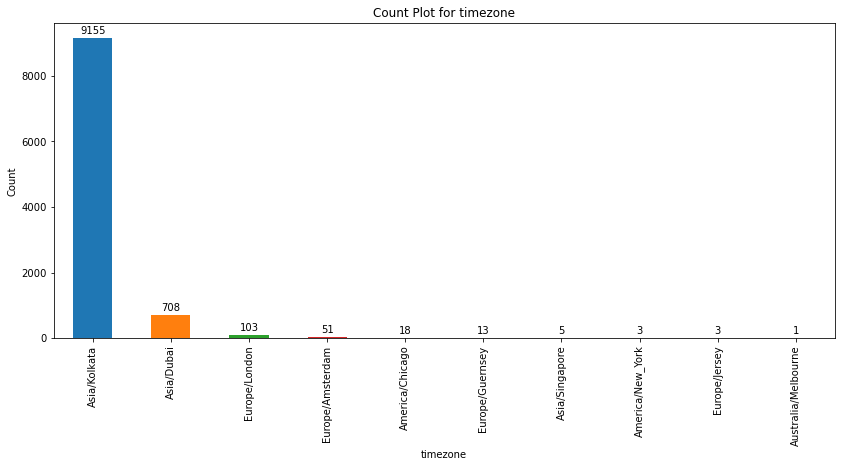

```python
for i in ['IP_version', 'city', 'region', 'country', 'loc', 'org', 'postal', 'timezone']:
    if merged_data[i].nunique() < 10:
        count_plot(merged_data, i, size=(6,5))
    else:
        count_plot(merged_data, i  )
```

```python
import folium
```

```python
IP_data[IP_data['Latitude'].isnull()].dropna()
```

```python
IP_data[IP_data['Longitude'].isnull()]
```

```python
for lat, lon in zip(IP_data['Latitude'].dropna().values, IP_data['Longitude'].dropna().values):
    m = folium.Map( location=[ lat, lon] )
```

```python
# m=folium.Map(location=[28.644800, 77.216721], zoom_start=5)
# for lat, lon in zip(IP_data['Latitude'].dropna().values, IP_data['Longitude'].dropna().values):
#     folium.Map( location=[ lat, lon] ).add_to(m)

# m
```

```python
# from branca.element import Figure
# fig=Figure(width=550,height=350)
```

```python
# m1=folium.Map(width=550,height=350,location=[28.644800, 77.216721],zoom_start=11,min_zoom=8,max_zoom=14)
# fig.add_child(m1)
# m1
```

```python
IP_data['Longitude'] = IP_data['loc'].str.split(',').str[0].values
IP_data['Latitude'] = IP_data['loc'].str.split(',').str[1].values
```

```python
IP_data.head()
```

[output not shown]

```python
# Maharashtra_city_long = IP_data[IP_data["region"] == "Maharashtra"].Longitude.values
# Maharashtra_city_lat = IP_data[IP_data["region"] == "Maharashtra"].Latitude.values
```

```python
# m = folium.Map(location=[Maharashtra_city_long, Maharashtra_city_lat])
# m
```

```python
# IP_data[IP_data["region"] == "Maharashtra"].Longitude.values
```

```python
# india_geojson=geopandas.read_file('india.json')
# india_geojson.head()
```

## eventType

```python
merged_data['eventType'].value_counts()
```

```
Cricket    6788
Soccer     1885
Tennis     1393
Name: eventType, dtype: int64
```

```python
# change_dtype_cat(merged_data, 'eventType')
```

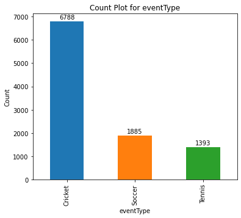

```python
count_plot(merged_data, 'eventType', size=(6,5))
```

```
---------------------------------
eventType grouped by status Count
---------------------------------
```

| status eventType | INVALID_BET | WINNER_DECLARED |
| --- | --- | --- |
| Cricket | 32 | 6756 |
| Soccer | 30 | 1855 |
| Tennis | 4 | 1389 |

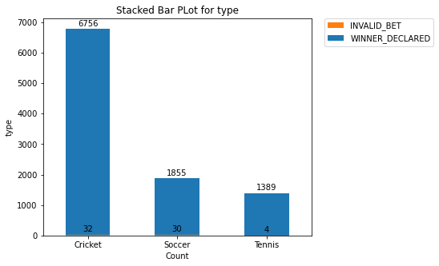

```python
crosstab_by_y_plot(merged_data, 'eventType', figsize=(6,5))
```

## userName

```python
merged_data['userName'].nunique()
```

```
410
```

```python
# merged_data['userName'].value_counts()
```

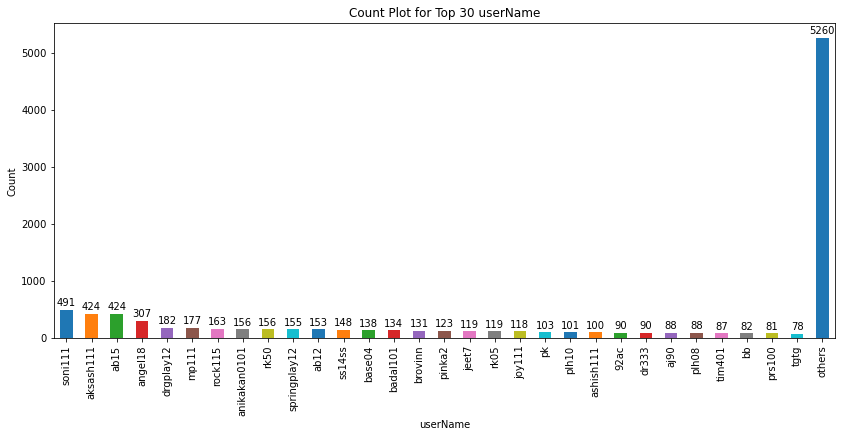

```python
count_plot(merged_data, 'userName')
```

```python
# crosstab_by_y_plot(merged_data, 'userName')
```

```python
crosstab_by_y_table(merged_data,'userName', top=10)
```

```
--------------------------------------------------
Top 10 userName by WINNER_DECLARED and INVALID_BET
--------------------------------------------------
```

| status userName | WINNER_DECLARED |
| --- | --- |
| soni111 | 489 |
| ab15 | 424 |
| aksash111 | 424 |
| angel18 | 307 |
| drgplay12 | 182 |
| mp111 | 177 |
| rock115 | 163 |
| rk50 | 156 |
| anikakan0101 | 155 |
| springplay12 | 155 |

| status userName | INVALID_BET |
| --- | --- |
| broraj1 | 3 |
| jk100p | 3 |
| ludo02 | 3 |
| ashu61 | 3 |
| chomo111 | 2 |
| soni111 | 2 |
| bhush001 | 2 |
| sony453 | 2 |
| raja90 | 2 |
| ri786 | 2 |

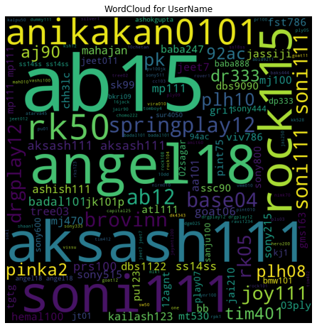

```python
word_list = []
import matplotlib.pyplot as plt
from wordcloud import WordCloud, STOPWORDS

for val in merged_data.userName:
    val = str(val).strip().replace(" ", "_")
    word_list.append(val)

# Converts each token into lowercase
for i in range(len(word_list)):
    word_list[i] = word_list[i].lower()

wc = ' '.join(str(e) for e in word_list)
wordcloud = WordCloud(width = 800, height = 800,
            background_color ='black',
            min_font_size = 10).generate(wc)

# plot the WordCloud image
plt.figure(figsize = (6, 6), facecolor = None)
plt.imshow(wordcloud)
plt.axis("off")
plt.tight_layout(pad = 0)

plt.title("WordCloud for UserName")
plt.show()
```

## selectionName

```python
merged_data.selectionName.nunique()
```

```
318
```

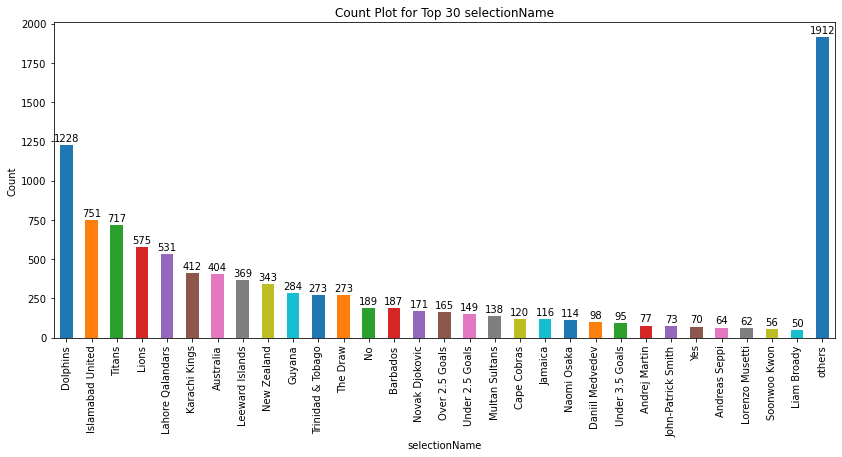

```python
count_plot(merged_data, 'selectionName')
```

```python
crosstab_by_y_table(merged_data, 'selectionName', top=20)
```

```
-------------------------------------------------------
Top 20 selectionName by WINNER_DECLARED and INVALID_BET
-------------------------------------------------------
```

| status selectionName | WINNER_DECLARED |
| --- | --- |
| Dolphins | 1228 |
| Islamabad United | 751 |
| Titans | 717 |
| Lions | 573 |
| Lahore Qalandars | 531 |
| Karachi Kings | 412 |
| Australia | 404 |
| Leeward Islands | 369 |
| New Zealand | 343 |
| Guyana | 284 |
| Trinidad & Tobago | 273 |
| The Draw | 267 |
| No | 189 |
| Barbados | 187 |
| Novak Djokovic | 171 |
| Over 2.5 Goals | 163 |
| Under 2.5 Goals | 148 |
| Multan Sultans | 138 |
| Cape Cobras | 120 |
| Jamaica | 116 |

| status selectionName | INVALID_BET |
| --- | --- |
| West Indies | 13 |
| Over 1.5 Goals | 7 |
| The Draw | 6 |
| Canterbury | 3 |
| Hugo Dellien | 3 |
| Sunrisers Hyderabad | 3 |
| Delhi Capitals | 3 |
| Werder Bremen | 2 |
| Pakistan | 2 |
| Over 2.5 Goals | 2 |
| Lions | 2 |
| Northern Knights | 1 |
| Sivasspor | 1 |
| Northeast United | 1 |
| Boavista | 1 |
| Over 7.5 Goals | 1 |
| Granada | 1 |
| Under 2.5 Goals | 1 |
| Reims | 1 |
| Sociedad | 1 |

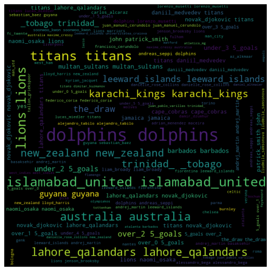

```python
word_list = []
import matplotlib.pyplot as plt
from wordcloud import WordCloud, STOPWORDS
import re

for val in merged_data.selectionName:
    val = str(val).strip().replace(" ", "_")
    val = re.sub(r'\s+', '',val)
    word_list.append(val)

# Converts each token into lowercase
for i in range(len(word_list)):
    word_list[i] = word_list[i].lower()

wc = ' '.join(str(e) for e in word_list)
wordcloud = WordCloud(width = 800, height = 800,
            background_color ='black',
            min_font_size = 10).generate(wc)

# plot the WordCloud image
plt.figure(figsize = (8, 6), facecolor = None)
plt.imshow(wordcloud)
plt.axis("off")
plt.tight_layout(pad = 0)

plt.show()
```

## marketName

```python
merged_data['marketName'].unique()
```

```
array(['Match Odds', 'Tied Match', 'Over/Under 2.5 Goals',
       'Over/Under 3.5 Goals', 'Over/Under 1.5 Goals',
       'Over/Under 4.5 Goals', 'Over/Under 5.5 Goals',
       'Over/Under 0.5 Goals', 'Over/Under 6.5 Goals',
       'Over/Under 7.5 Goals'], dtype=object)
```

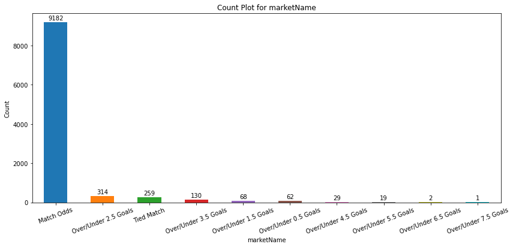

```python
count_plot(merged_data, 'marketName', rotation=20)
```

```python
# crosstab_by_y_table(merged_data, 'marketName', top=None)
```

```
----------------------------------
marketName grouped by status Count
----------------------------------
```

| status marketName | INVALID_BET | WINNER_DECLARED |
| --- | --- | --- |
| Match Odds | 55 | 9127 |
| Over/Under 0.5 Goals | 0 | 62 |
| Over/Under 1.5 Goals | 7 | 61 |
| Over/Under 2.5 Goals | 3 | 311 |
| Over/Under 3.5 Goals | 0 | 130 |
| Over/Under 4.5 Goals | 0 | 29 |
| Over/Under 5.5 Goals | 0 | 19 |
| Over/Under 6.5 Goals | 0 | 2 |
| Over/Under 7.5 Goals | 1 | 0 |
| Tied Match | 0 | 259 |

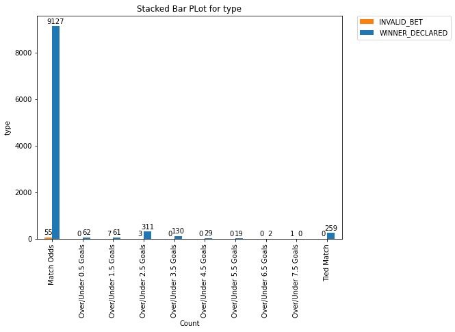

```python
crosstab_by_y_plot(merged_data, 'marketName', stacked=False, rotation=90)
```

## event

```python
merged_data['event'].nunique()
```

```
245
```

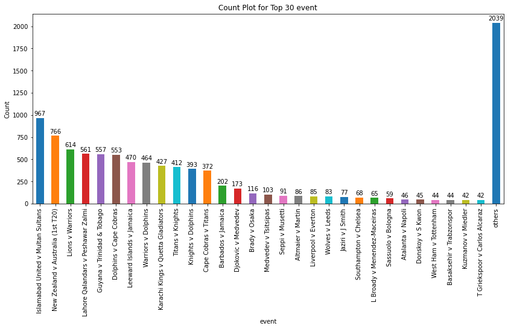

```python
count_plot(merged_data, 'event')
```

```python
crosstab_by_y_table(merged_data, 'event')
```

```
-----------------------------------------------
Top 10 event by WINNER_DECLARED and INVALID_BET
-----------------------------------------------
```

| status event | WINNER_DECLARED |
| --- | --- |
| Islamabad United v Multan Sultans | 967 |
| New Zealand v Australia (1st T20) | 766 |
| Lions v Warriors | 612 |
| Lahore Qalandars v Peshawar Zalmi | 561 |
| Guyana v Trinidad & Tobago | 557 |
| Dolphins v Cape Cobras | 553 |
| Leeward Islands v Jamaica | 470 |
| Warriors v Dolphins | 464 |
| Karachi Kings v Quetta Gladiators | 427 |
| Titans v Knights | 412 |

| status event | INVALID_BET |
| --- | --- |
| Bangladesh v West Indies | 14 |
| Pakistan v South Africa | 5 |
| Hapoel Beer Sheva v Nice | 5 |
| Delhi Capitals v Royal Challengers Bangalore | 3 |
| Sunrisers Hyderabad v Mumbai Indians | 3 |
| Central Districts v Canterbury | 3 |
| Casanova v Dellien | 3 |
| US Cremonese v Brescia | 2 |
| Lions v Warriors | 2 |
| Werder Bremen v Schalke 04 | 2 |

## winnerId

```python
merged_data['winnerId'].nunique()
```

```
195
```

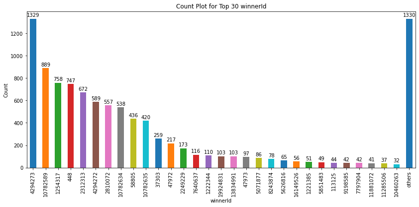

```python
count_plot(merged_data, 'winnerId')
```

```python
crosstab_by_y_table(merged_data, 'winnerId')
```

```
--------------------------------------------------
Top 10 winnerId by WINNER_DECLARED and INVALID_BET
--------------------------------------------------
```

| status winnerId | WINNER_DECLARED |
| --- | --- |
| 4294273 | 1329 |
| 10782589 | 889 |
| 1254317 | 758 |
| 448 | 747 |
| 2312313 | 672 |
| 4294272 | 587 |
| 2810072 | 557 |
| 10782634 | 538 |
| 58805 | 427 |
| 10782635 | 420 |

| status winnerId | INVALID_BET |
| --- | --- |
| 235 | 14 |
| 58805 | 9 |
| 7461 | 5 |
| 1221385 | 5 |
| 22121561 | 3 |
| 86363 | 3 |
| 8226987 | 3 |
| 7671296 | 3 |
| 4294272 | 2 |
| 1221386 | 2 |

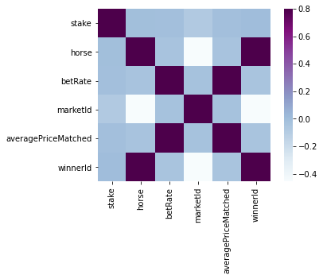

```python
sns.heatmap(merged_data.corr(), vmax=.8, square=True, cmap="BuPu");
```

## Numerical Features

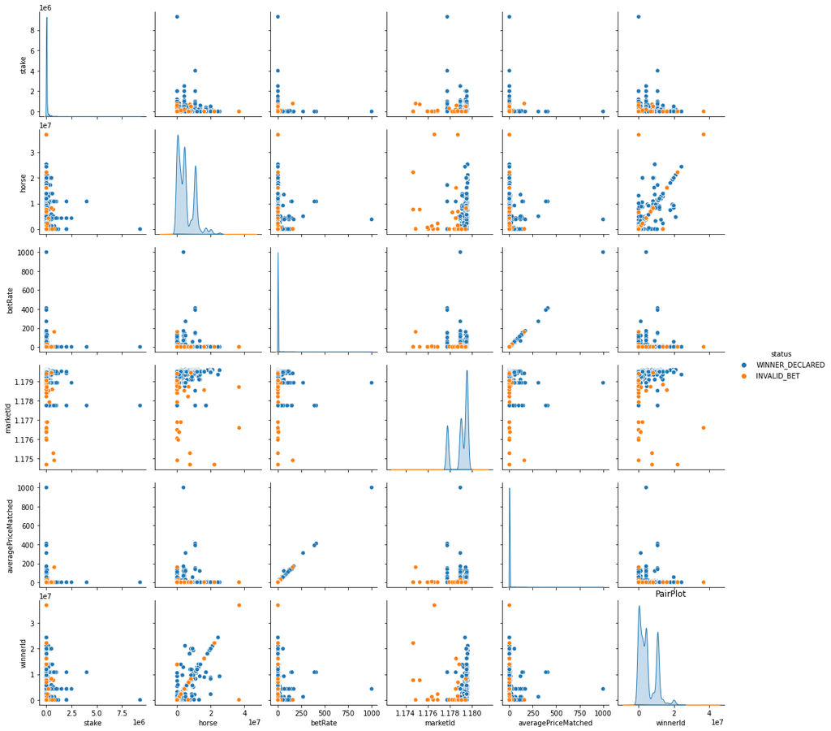

```
Wall time: 34 s
```

```python
%%time
sns.pairplot(merged_data, hue='status')
plt.title('PairPlot')
plt.show()
```